# InVivoStat Unpaired t-test Analysis

## Response

The Resp 1 response is currently being analysed by the Unpaired t-test Analysis module.

The response has been log10 transformed prior to analysis.

For more information on the theoretical approaches that are implemented within this module, see Bate and Clark (2014).

## Scatterplot of the observed data (on the log10 scale)

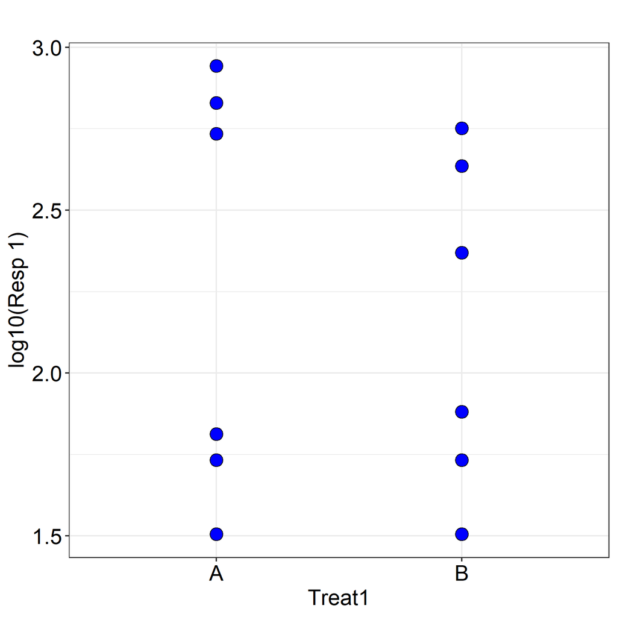

Tip: Use this plot to identify possible outliers.

## Statistical analysis results assuming equal variances

### Unpaired t-test result

|  | t-statistic | Degrees of freedom | p-value |
| --- | --- | --- | --- |
| Equal variance unpaired t-test | 0.339 | 10 | 0.7413 |

Conclusion: At the 10% level, the difference between the levels of Resp 1 is not statistically significant.

### Table of the least square (predicted) means with 90% confidence intervals

| Treatment level | Mean | Lower 90% CI | Upper 90% CI |
| --- | --- | --- | --- |
| A | 2.260 | 1.830 | 2.689 |
| B | 2.146 | 1.716 | 2.575 |

### Comparison of the least square (predicted) means with 90% confidence interval

| Comparison | Difference | Lower 90% CI | Upper 90% CI | Std error | p-value |
| --- | --- | --- | --- | --- | --- |
| A - B | 0.114 | -0.494 | 0.721 | 0.335 | 0.7413 |

### Table of the back-transformed geometric means with 90% confidence intervals

As the response was log transformed prior to analysis the least square (predicted) means are presented on the log scale. These results can be back transformed onto the original scale. These are known as the back-transformed geometric means.

| Treatment level | Geometric mean | Lower 90% CI | Upper 90% CI |
| --- | --- | --- | --- |
| A | 181.765 | 67.590 | 488.806 |
| B | 139.869 | 52.011 | 376.139 |

### Comparison of the geometric means as a back-transformed ratio

As the response was log transformed prior to analysis the differences between the least square (predicted) means are presented on the log scale. These results can be back-transformed onto the original scale, where differences on the log scale become ratios when back-transformed.

| Comparison | Ratio | Lower 90% CI | Upper 90% CI | p-value |
| --- | --- | --- | --- | --- |
| A / B | 1.300 | 0.321 | 5.265 | 0.7413 |

## Diagnostic plots (assuming equal variances)

### Residuals vs. predicted plot

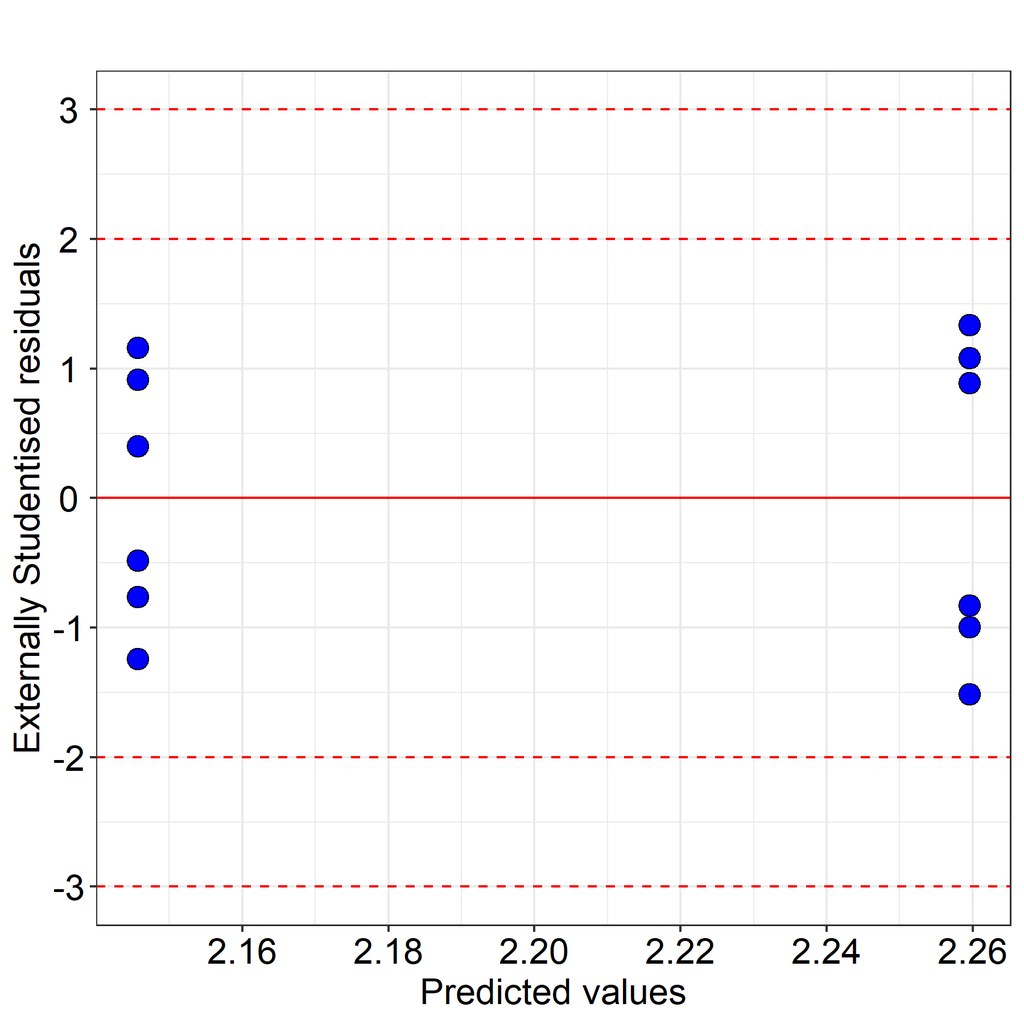

Tip: On this plot look to see if the spread of the points increases as the predicted values increase. If so the response may need transforming or the unequal variance assumption selected.

Tip: Any observation with a residual less than -3 or greater than 3 (SD) should be investigated as a possible outlier.

### Normal probability plot

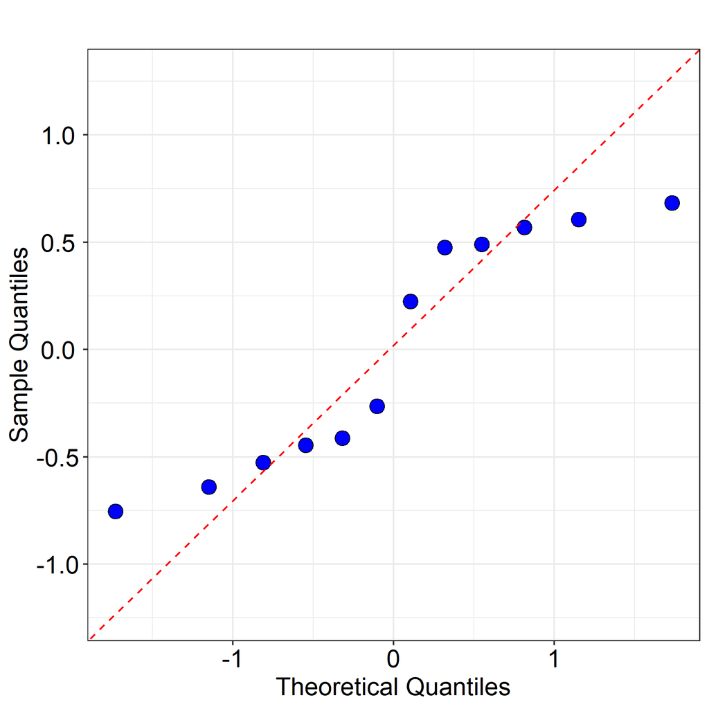

Tip: Check that the points lie along the dotted line. If not then the data may be non-normally distributed.

## Statistical analysis results assuming unequal variances

The analysis presented is Welch's t-test assuming unequal variances, Welch (1947).

### Unpaired t-test result

|  | t-statistic | Degrees of freedom | p-value |
| --- | --- | --- | --- |
| Unequal variance unpaired t-test | 0.339 | 9.52 | 0.7416 |

Conclusion: At the 10% level, the difference between the levels of Resp 1 is not statistically significant.

## Diagnostic plots (assuming unequal variances)

### Residuals vs. predicted plot

This plot is not available for the unequal variance case.

### Normal probability plot

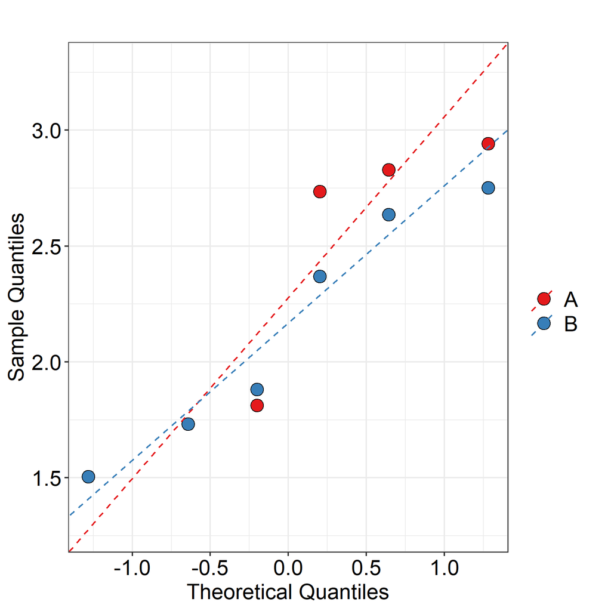

Note: The normal probability plot includes one line per group as the variances are estimated separately for each group.

Tip: Check that the points lie along the dotted line. If not then the data may be non-normally distributed.

### Table of the least square (predicted) means with 90% confidence intervals

| Treatment level | Mean | Lower 90% CI | Upper 90% CI |
| --- | --- | --- | --- |
| A | 2.260 | 1.731 | 2.788 |
| B | 2.146 | 1.725 | 2.566 |

### Comparison of the least square (predicted) means with 90% confidence interval

| Comparison | Difference | Lower 90% CI | Upper 90% CI | p-value |
| --- | --- | --- | --- | --- |
| A - B | 0.114 | -0.497 | 0.724 | 0.7416 |

### Table of the back-transformed geometric means with 90% confidence intervals

As the response was log transformed prior to analysis the least square (predicted) means are presented on the log scale. These results can be back transformed onto the original scale. These are known as the back-transformed geometric means.

| Treatment level | Geometric Mean | Lower 90% CI | Upper 90% CI |
| --- | --- | --- | --- |
| A | 181.765 | 53.833 | 613.729 |
| B | 139.869 | 53.087 | 368.515 |

### Comparison of the geometric means as a back-transformed ratio

As the response was log transformed prior to analysis the differences between the least square (predicted) means are presented on the log scale. These results can be back-transformed onto the original scale, where differences on the log scale become ratios when back-transformed.

| Comparison | Ratio | Lower 90% CI | Upper 90% CI | p-value |
| --- | --- | --- | --- | --- |
| A / B | 1.300 | 0.318 | 5.303 | 0.7416 |

## References

When referring to InVivoStat, please cite 'InVivoStat, version 5.2.0'.

Bate, S.T. and Clark, R.A. (2014). The Design and Statistical Analysis of Animal Experiments. Cambridge University Press.

Welch, B.L. (1947). The generalization of Student's problem when several different population variances are involved. Biometrika, 34(1-2), 28-35.